[figure not shown]

# Assignment 5

In this assignment, you'll scrape text from [The California Aggie](https://theaggie.org/) and then analyze the text.

The Aggie is organized by category into article lists. For example, there's a [Campus News](https://theaggie.org/campus/) list, [Arts & Culture](https://theaggie.org/arts/) list, and [Sports](https://theaggie.org/sports/) list. Notice that each list has multiple pages, with a maximum of 15 articles per page.

The goal of exercises 1.1 - 1.3 is to scrape articles from the Aggie for analysis in exercise 1.4.

I am going to be using BeautifulSoup to scrape HTML throughout this assignment. </font>

```python
from bs4 import BeautifulSoup
import requests_cache
import requests
import numpy as np
import pandas as pd
import re
from wordcloud import WordCloud, STOPWORDS
import random

# START CACHING
requests_cache.install_cache("demo_cache")
```

# Exercise 1.1

Write a function that extracts all of the links to articles in an Aggie article list. The function should:

- Have a parameter `url` for the URL of the article list.
- Have a parameter `page` for the number of pages to fetch links from. The default should be `1`.
- Return a list of aricle URLs (each URL should be a string).

Test your function on 2-3 different categories to make sure it works.

Hints:

- Be polite to The Aggie and save time by setting up [requests_cache](https://pypi.python.org/pypi/requests-cache) before you write your function.
- Start by getting your function to work for just 1 page. Once that works, have your function call itself to get additional pages.
- You can use [lxml.html](http://lxml.de/lxmlhtml.html) or [BeautifulSoup](https://www.crummy.com/software/BeautifulSoup/bs4/doc/) to scrape HTML. Choose one and use it throughout the entire assignment.

The following cell contains a function to extract URLs from one page of the Aggie. </font>

```python
# FUNCTION TO RETRIEVE URLS FROM ONE PAGE

def one_page_links(url):
    soup = BeautifulSoup((requests.get(url)).text, "html.parser")
    articles = soup.find_all("h2")
    return([x.find_all("a")[0]["href"] for x in articles])
```

The following function generalizes the above function to work for the desired amount of pages. </font>

```python
# FUNCTION TO RETRIEVE URLS FROM ONE OR MORE PAGES
# URL NEEDS TO HAVE THE FORWARD /
def extract_links(url, page=1):
    if page == 1:
        return(one_page_links(url))
    if page > 1:
        pages_wanted = [url+"page/"+str(x)+"/" for x in range(1,page+1)]
        all_articles = [one_page_links(page) for page in pages_wanted]
        return([item for sublist in all_articles for item in sublist])
```

I tested my function for the following article lists: (1) science, (2) sports, and (3) opinion. </font>

```python
# extract_links FUNCTION TESTING
#extract_links("https://theaggie.org/sciencetech/", 10)
#extract_links("https://theaggie.org/sports/", 2)
#extract_links("https://theaggie.org/opinion/", 1)
```

# Exercise 1.2

Write a function that extracts the title, text, and author of an Aggie article. The function should:

- Have a parameter `url` for the URL of the article.
- For the author, extract the "Written By" line that appears at the end of most articles. You don't have to extract the author's name from this line.
- Return a dictionary with keys "url", "title", "text", and "author". The values for these should be the article url, title, text, and author, respectively.

For example, for [this article](https://theaggie.org/2017/02/14/project-toto-aims-to-address-questions-regarding-city-finances/) your function should return something similar to this:

```
{
    'author': u'Written By: Bianca Antunez \xa0\u2014\xa0city@theaggie.org',
    'text': u'Davis residents create financial model to make city\'s financial state more transparent To increase transparency between the city\'s financial situation and the community, three residents created a model called Project Toto which aims to improve how the city communicates its finances in an easily accessible design. Jeff Miller and Matt Williams, who are members of Davis\' Finance and Budget Commission, joined together with Davis entrepreneur Bob Fung to create the model plan to bring the project to the Finance and Budget Commission in February, according to Kelly Stachowicz, assistant city manager. "City staff appreciate the efforts that have gone into this, and the interest in trying to look at the city\'s potential financial position over the long term," Stachowicz said in an email interview. "We all have a shared goal to plan for a sound fiscal future with few surprises. We believe the Project Toto effort will mesh well with our other efforts as we build the budget for the next fiscal year and beyond." Project Toto complements the city\'s effort to amplify the transparency of city decisions to community members. The aim is to increase the understanding about the city\'s financial situation and make the information more accessible and easier to understand. The project is mostly a tool for public education, but can also make predictions about potential decisions regarding the city\'s financial future. Once completed, the program will allow residents to manipulate variables to see their eventual consequences, such as tax increases or extensions and proposed developments "This really isn\'t a budget, it is a forecast to see the intervention of these decisions," Williams said in an interview with The Davis Enterprise. "What happens if we extend the sales tax? What does it do given the other numbers that are in?" Project Toto enables users, whether it be a curious Davis resident, a concerned community member or a city leader, with the ability to project city finances with differing variables. The online program consists of the 400-page city budget for the 2016-2017 fiscal year, the previous budget, staff reports and consultant analyses. All of the documents are cited and accessible to the public within Project Toto. "It\'s a model that very easily lends itself to visual representation," Mayor Robb Davis said. "You can see the impacts of decisions the council makes on the fiscal health of the city." Complementary to this program, there is also a more advanced version of the model with more in-depth analyses of the city\'s finances. However, for an easy-to-understand, simplistic overview, Project Toto should be enough to help residents comprehend Davis finances. There is still more to do on the project, but its creators are hard at work trying to finalize it before the 2017-2018 fiscal year budget. "It\'s something I have been very much supportive of," Davis said. "Transparency is not just something that I have been supportive of but something we have stated as a city council objective [ ] this fits very well with our attempt to inform the public of our challenges with our fiscal situation." ',
    'title': 'Project Toto aims to address questions regarding city finances',
    'url': 'https://theaggie.org/2017/02/14/project-toto-aims-to-address-questions-regarding-city-finances/'
}
```

Hints:

- The author line is always the last line of the last paragraph.
- Python 2 displays some Unicode characters as `\uXXXX`. For instance, `\u201c` is a left-facing quotation mark. You can convert most of these to ASCII characters with the method call (on a string)

  ```
  .translate({ 0x2018:0x27, 0x2019:0x27, 0x201C:0x22, 0x201D:0x22, 0x2026:0x20 })
  ```

  If you're curious about these characters, you can look them up on [this page](http://unicode.org/cldr/utility/character.jsp), or read more about [what Unicode is](http://unicode.org/standard/WhatIsUnicode.html).

This function gets article info. The parameter is the URL for a given article. I have some error handling, just in case some of the articles were formatted differently. </font>

```python
def get_article_info(url):
    # PARSING
    this_request = requests.get(url).text
    abc_soup = BeautifulSoup(this_request, "html.parser")
    article_body = abc_soup.find_all("div", {"itemprop", "articleBody"})
    entry_content = abc_soup.find_all("div", {"class", "entry-content"})[0]

    # AUTHOR
    article = str([s.text for s in abc_soup.findAll("div") if s.get("itemprop") == "articleBody"])
    try:
        author = re.split("Written [Bb]y: ", article, re.IGNORECASE)[1]
        author = re.split("\\", author.encode('ascii', 'ignore'))[0]
    except:
        try:
            m = re.search("Written [Bb]y: [A-z]{1,14} [A-z]{3,15}", abc_soup.text)
            author = m.group(0)
            author = re.split("Written [Bb]y: ", author)[1]
        except:
            author = np.NaN

    # TITLE
    try:
        title = abc_soup.find_all("h1", {"class": "entry-title"})[0].text.encode('ascii', 'ignore')
    except:
        try:
            title = article_body.find_all("strong")[0].text.encode('ascii', 'ignore')
        except:
            title = np.NaN

    # ENTRY
    paragraphs = [entry_content.find_all("span", { "style" : "font-weight: 400;" })[x].text for x in range(len(entry_content.find_all("span", { "style" : "font-weight: 400;" })))]
    entry = "".join(paragraphs[:-1]).strip()
    entry = entry.encode('ascii', 'ignore')

    this_dic = {"author": author, "text": entry, "title": title, "url": url}
    return(this_dic)
```

```python
# FUNCTION TESTING
#get_article_info("https://theaggie.org/2017/02/14/project-toto-aims-to-address-questions-regarding-city-finances/")
#get_article_info("https://theaggie.org/2017/02/15/suspect-in-davis-islamic-center-vandalism-arrested/")
#get_article_info("https://theaggie.org/2017/02/12/the-bachelor-engages-viewers-prompts-viewing-rituals/")
```

# Exercise 1.3

Use your functions from exercises 1.1 and 1.2 to get a data frame of 60 [Campus News](https://theaggie.org/campus/) articles and a data frame of 60 [City News](https://theaggie.org/city/) articles. Add a column to each that indicates the category, then combine them into one big data frame.

The "text" column of this data frame will be your corpus for natural language processing in exercise 1.4.

I will use the Pandas DataFrame function on a list of dictionaries. </font>

```python
# CAMPUS AND CITY NEWS ARTICLES
links = extract_links("https://theaggie.org/campus/", page=4) + extract_links("https://theaggie.org/city/", page=4)
print len(links)
dictionaries = [get_article_info(x) for x in links]

news_df = pd.DataFrame(dictionaries)
```

```
120
```

```python
# ADD THE SOURCES
x = np.array(["campus", "city"])
news_df["source"] = np.repeat(x, [60, 60], axis=0)
```

```python
news_df.drop_duplicates()
```

|  | author | text | title | url | source |
| --- | --- | --- | --- | --- | --- |
| 0 | Kaitlyn Cheung | UC Davis students and community members protes... | UC Davis students participate in UC-wide #NoDA... | https://theaggie.org/2017/02/17/uc-davis-stude... | campus |
| 1 | Jayashri Padmanabhan | UC Davis held its first mental health conferen... | UC Davis holds first mental health conference | https://theaggie.org/2017/02/17/uc-davis-holds... | campus |
| 2 | Demi Caceres | The ASUCD Senate meeting was called to order b... | Last week in Senate | https://theaggie.org/2017/02/16/last-week-in-s... | campus |
| 3 | Alyssa Vandenberg | Executive: Josh Dalavai and Adilla JamaludinIn... | 2017 ASUCD Winter Elections Meet the Candidates | https://theaggie.org/2017/02/16/2017-asucd-win... | campus |
| 4 | Ivan Valenzuela | A new exhibit recently opened at Peter J. Shie... | Shields Library hosts new exhibit for Davis ce... | https://theaggie.org/2017/02/14/shields-librar... | campus |
| 5 | Demi Caceres | Students promote fruit and vegetable meals via... | Student Health and Counseling Services hosts S... | https://theaggie.org/2017/02/14/student-health... | campus |
| 6 | Lindsay Floyd | To compensate for a decrease in university-all... | PE classes may charge additional fees | https://theaggie.org/2017/02/13/pe-classes-may... | campus |
| 7 | Jeanna Totah | University News announced the names of the 11 ... | 11 new Chancellor Fellows honored for 2016 | https://theaggie.org/2017/02/12/11-new-chancel... | campus |
| 8 | Aaron Liss | The UC Davis Muslim Student Association (MSA) ... | Muslim students respond to recent political ev... | https://theaggie.org/2017/02/12/muslim-student... | campus |
| 9 | Lindsay Floyd | On Feb. 1, Student Health and Counseling Servi... | Sexcessful Campaign launched in time for Valen... | https://theaggie.org/2017/02/12/sexcessful-cam... | campus |
| 10 | Alyssa Vandenberg | Michael Chan, a fourth-year computer science m... | Michael Chan sworn in as interim senator | https://theaggie.org/2017/02/10/michael-chan-s... | campus |
| 11 | Kenton Goldsby | The Regents of the University of California (U... | University of California Regents meet, approve... | https://theaggie.org/2017/02/09/university-of-... | campus |
| 12 | Yvonne Leong | The ASUCD Senate meeting was called to order b... | Last week in Senate | https://theaggie.org/2017/02/09/last-week-in-s... | campus |
| 13 | Jayashri Padmanabhan | UC Davis received $2.2 million in state fundin... | UC Davis receives $2.2 million from Assembly B... | https://theaggie.org/2017/02/09/uc-davis-recei... | campus |
| 14 | Ivan Valenzuela | During the Davis College Democrats (DCD) secon... | Senator Bill Dodd visits UC Davis | https://theaggie.org/2017/02/06/senator-bill-d... | campus |
| 28 | Kenton Goldsby | One of the many new California laws that took ... | AB 1887 prevents use of state funds, including... | https://theaggie.org/2017/02/05/ab-1887-preven... | campus |
| 29 | Jayashri Padmanabhan | The University of California (UC) system annou... | UC system hires Title IX coordinator | https://theaggie.org/2017/02/02/uc-system-hire... | campus |
| 30 | Jeanna Totah | The second ASUCD Senate meeting of the new yea... | Last week in Senate | https://theaggie.org/2017/02/02/last-week-in-s... | campus |
| 31 | Demi Caceres | The UC Davis Horse Barn at the Cole Facility r... | Action Jackson famous breeding donkey dies a... | https://theaggie.org/2017/02/02/action-jackson... | campus |
| 32 | Alyssa Vandenberg | On Jan. 19, ASUCD Senator Sam Park resigned fr... | ASUCD Senator Sam Park resigns | https://theaggie.org/2017/02/02/asucd-senator-... | campus |
| 33 | Demi Caceres | Recent UC Davis graduate Chris Tung along with... | UC Davis graduate creates online website to co... | https://theaggie.org/2017/01/31/uc-davis-gradu... | campus |
| 34 | Jeanna Totah | Due to the passing of state law on Jan. 1, the... | UC Davis plans to bottle student wine for $80 | https://theaggie.org/2017/01/30/uc-davis-plans... | campus |
| 35 | Jayashri Padmanabhan | UC Davis will host its first ever mental healt... | UC Davis to host first ever mental health conf... | https://theaggie.org/2017/01/30/uc-davis-to-ho... | campus |
| 36 | Ivan Valenzuela | The Sexual Violence Awareness and Education (S... | UC Davis Sexual Violence Awareness and Educati... | https://theaggie.org/2017/01/29/uc-davis-sexua... | campus |
| 37 | Yvonne Leong | At the end of , the French Embassy in Washingt... | UC Davis study abroad secures $22,000 in grant... | https://theaggie.org/2017/01/29/uc-davis-study... | campus |
| 38 | Alyssa Vandenberg | On Thursday, Jan. 26, the UC Regents voted to ... | UC Regents vote to raise tuition for UC campuses | https://theaggie.org/2017/01/27/uc-regents-vot... | campus |
| 39 | Aaron Liss | Kevin Samy, former speechwriter to the Obama A... | Former White House speechwriter comes to UC Davis | https://theaggie.org/2017/01/26/former-white-h... | campus |
| 40 | Jayashri Padmanabhan | ASUCD held its first senate meeting of Winter ... | Last week in Senate | https://theaggie.org/2017/01/26/last-week-in-s... | campus |
| 41 | Kenton Goldsby | A deluge of winter rain recently hit the UC Da... | Davis area receives nearly eight inches of rai... | https://theaggie.org/2017/01/26/davis-area-rec... | campus |
| 42 | Yvonne Leong | Approximately 30 protesters gathered at the Me... | Students walk out of classes to protest Trumps... | https://theaggie.org/2017/01/25/students-walk-... | campus |
| ... | ... | ... | ... | ... | ... |
| 90 | Raul Castellanos | Sweet, salty, sour and spicy. Thai food has it... | No such thing as too much Thai food | https://theaggie.org/2017/01/17/no-such-thing-... | city |
| 91 | Kaelyn Tuermer | For the past four years, the Petco Foundation ... | A dog named Disney wins grant money for Rotts ... | https://theaggie.org/2017/01/16/a-dog-named-di... | city |
| 92 | Andie Joldersma | Good news is in the air for Yolo County reside... | Yolo County Library materials to be more widel... | https://theaggie.org/2017/01/15/yolo-county-li... | city |
| 93 | Sam Solomon | Dec. 24Downstairs neighbor tapping on RPs floo... | Police Logs | https://theaggie.org/2017/01/12/police-logs-7/ | city |
| 94 | Dianna Rivera | The Davis Manor Neighborhood (DMN) celebrated ... | Neighbors unite | https://theaggie.org/2017/01/12/neighbors-unite/ | city |
| 95 | Kaelyn Tuermer | Many believe that standardized testing is a me... | Sparks fly in Light the Fire | https://theaggie.org/2016/12/09/sparks-fly-in-... | city |
| 96 | Raul Castellanos | Davis, California home to thousands of cyclis... | Bike Campaign offers bicycles to those who can... | https://theaggie.org/2016/12/09/bike-campaign-... | city |
| 97 | Juno Bhardwaj | On Nov. 19, the Davis Vanguard hosted its annu... | Bail reform advocates gather at annual fundraiser | https://theaggie.org/2016/12/08/bail-reform-ad... | city |
| 98 | Samantha Solomon | Celebrate the holidays 19th century style at O... | Twas the Night Before Christmas in Old Sacramento | https://theaggie.org/2016/12/07/twas-the-night... | city |
| 99 | Sam Solomon | Candles lit the streets of Davis on Dec. 1 as ... | Childrens Candlelight Parade lights up downtow... | https://theaggie.org/2016/12/05/childrens-cand... | city |
| 100 | Sam Solomon | Nov. 20Hydraulic lift parked across from RPs r... | Police Logs | https://theaggie.org/2016/12/04/police-logs-6/ | city |
| 101 | Dianna Rivera | The Yolo County Childrens Alliance (YCCA) held... | The season of giving | https://theaggie.org/2016/12/04/the-season-of-... | city |
| 102 | Samantha Solomon | As blue and red police lights wailed through t... | NoDAPL protest erupts in downtown Davis | https://theaggie.org/2016/12/02/nodapl-protest... | city |
| 103 | Andie Joldersma | Five, four, three, two, one Go!Those were the ... | Davis Turkey Trot: more than just another race | https://theaggie.org/2016/12/02/davis-turkey-t... | city |
| 104 | Andie Joldersma | With rising concerns of climate change, green ... | Affordable, clean, green energy is coming to Y... | https://theaggie.org/2016/11/30/affordable-cle... | city |
| 105 | Bianca Antunez | Since 1984, Davis residents have voted to supp... | Measure H passes, voters support Davis schools | https://theaggie.org/2016/11/29/measure-h-pass... | city |
| 106 | Anya Rehon | Overall trends of public intoxication arrests ... | Local residents attend Davis town hall meeting | https://theaggie.org/2016/11/29/local-resident... | city |
| 107 | Sam Solomon | Nov. 15Elderly driver not stopping at stop sig... | Police Logs | https://theaggie.org/2016/11/27/police-logs-5/ | city |
| 108 | Raul Castellanos | The public piano on the corner of Second and E... | Public piano destroyed in act of vandalism | https://theaggie.org/2016/11/27/public-piano-d... | city |
| 109 | Samantha Solomon | As darkness fell over the crowd of people who ... | Holding the Light | https://theaggie.org/2016/11/27/holding-the-li... | city |
| 110 | Dianna Rivera | It is 4:45 in the afternoon, and the sun is al... | Sun down, bike lights out | https://theaggie.org/2016/11/22/sun-down-bike-... | city |
| 111 | Sam Solomon | Nov. 7Subject stated our pizza is ready and th... | Police Logs | https://theaggie.org/2016/11/22/police-logs-4/ | city |
| 112 | Kaelyn Tuermer | One thing that Davis certainly doesnt have tre... | Tune in to Watermelon Musics strings-for-food ... | https://theaggie.org/2016/11/21/tune-in-to-wat... | city |
| 113 | Andie Joldersma | Water is sacred, water is life, chanted hundre... | Water is sacred, water is life | https://theaggie.org/2016/11/20/water-is-sacre... | city |
| 114 | Anya Rehon | The Yolo Food Bank (YFB) provides meals and ad... | The Yolo Food Bank addresses food insecurity | https://theaggie.org/2016/11/17/the-yolo-food-... | city |
| 115 | Bianca Antunez | As Election Day came to a close, and the resul... | Nov. 8 2016: An Election Day many may never fo... | https://theaggie.org/2016/11/17/nov-8-2016-an-... | city |
| 116 | NaN | Oct. 30Turkey in the roadway, vehicles stoppin... | Police Logs | https://theaggie.org/2016/11/15/police-logs-3/ | city |
| 117 | Bianca Antunez | For the eighth year in a row, the Yolo Food Ba... | Yolo Food Banks eighth Annual Running of the T... | https://theaggie.org/2016/11/15/yolo-food-bank... | city |
| 118 | Raul Castellanos | On the Monday before Election Day, energy ran ... | Return of the Bern | https://theaggie.org/2016/11/15/return-of-the-... | city |
| 119 | Alana Joldersma | Change is on its way to Davis Senior High Scho... | Construction of the All Student Center at Davi... | https://theaggie.org/2016/11/14/construction-o... | city |

101 rows × 5 columns

# Exercise 1.4

Use the Aggie corpus to answer the following questions. Use plots to support your analysis.

- What topics does the Aggie cover the most? Do city articles typically cover different topics than campus articles?
- What are the titles of the top 3 pairs of most similar articles? Examine each pair of articles. What words do they have in common?
- Do you think this corpus is representative of the Aggie? Why or why not? What kinds of inference can this corpus support? Explain your reasoning.

Hints:

- The [nltk book](http://www.nltk.org/book/) and [scikit-learn documentation](http://scikit-learn.org/stable/modules/feature_extraction.html#text-feature-extraction) may be helpful here.
- You can determine whether city articles are "near" campus articles from the similarity matrix or with k-nearest neighbors.
- If you want, you can use the [wordcloud](http://amueller.github.io/word_cloud/) package to plot a word cloud. To install the package, run

  ```
  conda install -c https://conda.anaconda.org/amueller wordcloud
  ```

  in a terminal. Word clouds look nice and are easy to read, but are less precise than bar plots.

**WARNING:** There is one function used in 1.4 that takes a very long time.  
**WARNING:** My analyses are TIME SENSITIVE. Re-running them at another time will produce other output because new articles are being written every day. </font>

```python
# NATURAL LANGUAGE PROCESSING
import nltk
# from nltk import word_tokenize
from nltk.tokenize import RegexpTokenizer
from nltk.stem.porter import PorterStemmer

# COUNTER CLASS
from collections import Counter

# SCIKIT LEARN
from sklearn.feature_extraction.text import TfidfVectorizer
from sklearn.neighbors import NearestNeighbors
from sklearn.neighbors import KNeighborsRegressor

# VISUALISATION
from matplotlib import pyplot as plt
%matplotlib inline
import wordcloud
from wordcloud import WordCloud, STOPWORDS
import random

# ELSE
from itertools import izip
```

<font size=4.5> The functions stem and lemmatize are from lesson 11. </font>

```python
stemmer = PorterStemmer().stem
tokenize = nltk.word_tokenize

def stem(tokens,stemmer = PorterStemmer().stem):
    return [stemmer(w.lower()) for w in tokens]

def lemmatize(text):
    """
    Extract simple lemmas based on tokenization and stemming
    Input: string
    Output: list of strings (lemmata)
    """
    return stem(tokenize(text))
```

## My Stopwords

<font size=4.5> I am defining my personal set of stopwords that relies on the STOPWORDS from the wordcloud library. </font>

```python
stopwords = STOPWORDS
more_stopwords = set(["said", "will", "really", "going", "might", "also", "come", "don't", "in", "UC", "Davis", "student", "students", "year", "city", "campus", "Day", "new", "News", "Last", "week", "Logs"])
stopwords = set(stopwords).union(more_stopwords)
```

## Topics Aggie Covers the Most

<font size=4.5> The Aggie covers community, people, events, senate, work, and state to name some. This makes sense because we examined two listings that have to do with campus and city news. The campus is very community centered, event centered, related to work, and political. City news is also political and covers ideas about state. </font>

```python
# RETURNS COUNTER CLASS
def get_em_tokens(some_text):
    # INITIALIZE TOKENIZER
    tokenizer = RegexpTokenizer(r'\w+')

    # MY STOP WORDS
    stops = STOPWORDS
    more_stopwords = set(["said", "will", "really", "going", "might", "also", "come", "don't", "in", "UC", "Davis", "student", "students", "year", "city", "campus", "Day", "new", "News", "Last", "week", "Logs"])
    stops = set(stops).union(more_stopwords)

    # REMOVE STOP WORDS FROM TOKENS
    tokens_no_stop = [i for i in tokenizer.tokenize(some_text) if not i in stops]

    # LEMMATIZE THE TOKENS
    lemmata = [lemmatize(x) for x in tokens_no_stop]
    lemmata2 = [item for sublist in lemmata for item in sublist]

    return Counter(lemmata2)
```

```python
overall_counts = get_em_tokens(news_df["text"][0])

for i in range(1, len(news_df["text"])):
    overall_counts = overall_counts + get_em_tokens(news_df["text"][i])

# FIRST TWO ARE "THE" and "I"
overall_counts.most_common()[0:12]
```

```
[('the', 471),
 ('i', 291),
 (u'commun', 226),
 (u'peopl', 188),
 ('one', 147),
 ('it', 143),
 (u'event', 143),
 (u'senat', 134),
 (u'work', 133),
 ('state', 127),
 (u'help', 124),
 ('we', 120)]
```

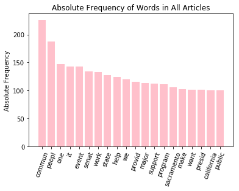

```python
df = pd.DataFrame.from_dict(overall_counts, orient='index').reset_index()
df = df.sort_values(by=0, ascending=False)

word = list(df.ix[:,0])[2:22]
count = list(df.ix[:,1])[2:22]

word_indices = np.arange(20) # ORDERED INDICES

## PLOTTING
plt.bar(word_indices, count, color="pink")
plt.xticks(word_indices, word, rotation=70)
plt.ylabel("Absolute Frequency")
plt.title("Absolute Frequency of Words in All Articles")

plt.show()
```

[figure not shown]

```python
this_text = list((" ".join(news_df["text"])).split(" "))
want = [item for item in this_text if item not in stopwords]
want = " ".join(want)


# GENERATE WORD CLOUD IMAGE
wc = WordCloud(background_color = "white", max_words=2000, stopwords=stopwords, width=800, height=400)

# GENERATE WORD CLOUD
wc.generate(want)

# COLORING
def grey_color_func(word, font_size, position, orientation, random_state=None, **kwargs):
    return "hsl(50, 0%%, %d%%)" % random.randint(10, 50)


# PLOTTING
plt.figure(figsize=(20,10))
plt.imshow(wc.recolor(color_func = grey_color_func, random_state=3))
plt.axis("off")
plt.tight_layout(pad=0)
plt.show()
```

## Topics That Campus Listing Covers Most

<font size=4.5> The Campus listing covers senate, community, university, work, major, event, and ASUCD. This makes sense because the UC Davis campus has a lot to do with the student senate, making community efforts to keep peace on campus, and UC Davis is a university so the word must come up a lot when talking about the school. ASUCD is also really common because candidates are often features in Aggie articles. </font>

```python
campus_df = news_df[news_df["source"] == "campus"]
campus_counts = get_em_tokens(campus_df["text"][0])

for i in range(1, 60):
     campus_counts = campus_counts + get_em_tokens(campus_df["text"][i])

campus_counts.most_common()[0:12]
```

```
[('the', 263),
 ('i', 189),
 (u'senat', 131),
 (u'commun', 116),
 (u'univers', 94),
 (u'work', 92),
 (u'event', 89),
 ('major', 89),
 (u'peopl', 88),
 ('asucd', 78),
 ('want', 75),
 (u'presid', 74)]
```

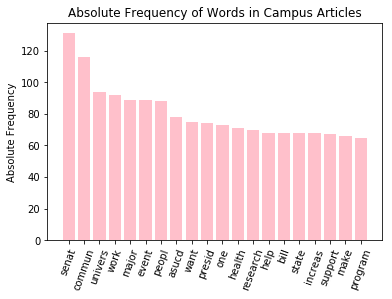

```python
df = pd.DataFrame.from_dict(campus_counts, orient='index').reset_index()
df = df.sort_values(by=0, ascending=False)

word = list(df.ix[:,0])[2:22]
count = list(df.ix[:,1])[2:22]

word_indices = np.arange(20) # ORDERED INDICES

## PLOTTING
plt.bar(word_indices, count, color="pink")
plt.xticks(word_indices, word, rotation=70)
plt.ylabel("Absolute Frequency")
plt.title("Absolute Frequency of Words in Campus Articles")

plt.show()
```

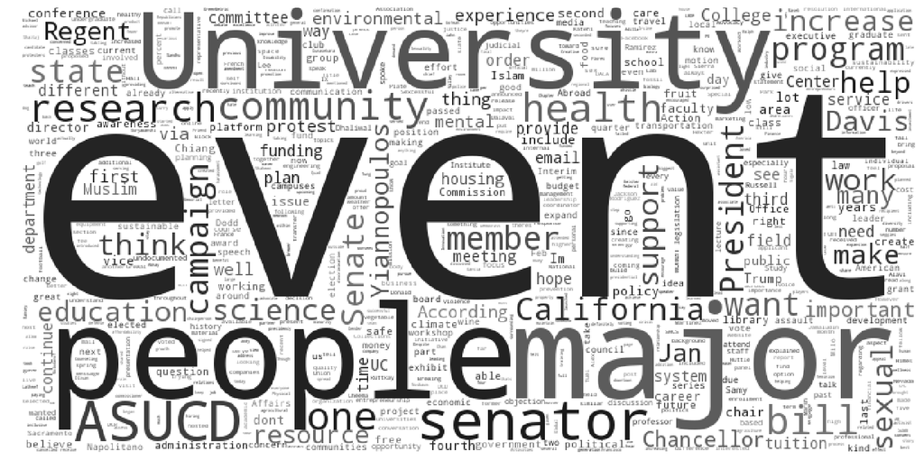

```python
this_text = list((" ".join(news_df["text"][news_df["source"] == "campus"])).split(" "))
want = [item for item in this_text if item not in stopwords]
want = " ".join(want)


# GENERATE WORD CLOUD IMAGE
wc = WordCloud(background_color = "white", max_words=2000, stopwords=stopwords, width=800, height=400)

# GENERATE WORD CLOUD
wc.generate(want)

# COLORING
def grey_color_func(word, font_size, position, orientation, random_state=None, **kwargs):
    return "hsl(50, 0%%, %d%%)" % random.randint(10, 50)


# PLOTTING
plt.figure(figsize=(20,10))
plt.imshow(wc.recolor(color_func = grey_color_func, random_state=3))
plt.axis("off")
plt.tight_layout(pad=0)
plt.show()
```

## Topics That City Listing Covers the Most

<font size=4.5> The City listing covers people, Sacramento, music, counties, public, and food to name a few. This makes sense because Davis has much to do about what people are up to in the city, Sacramento is a neighboring city to Davis, music is very popular overall in city life, and college students are very interested in food. These students call themselves "foodies". </font>

```python
city_df = news_df[news_df["source"] == "city"]
city_counts = get_em_tokens(city_df["text"][60])

for i in range(61, 120):
    city_counts = city_counts + get_em_tokens(city_df["text"][i])

city_counts.most_common()[0:12]
```

```
[('the', 208),
 (u'commun', 110),
 ('i', 102),
 (u'peopl', 100),
 ('sacramento', 91),
 (u'it', 83),
 (u'one', 74),
 ('music', 73),
 (u'counti', 72),
 ('public', 71),
 (u'citi', 68),
 ('food', 63)]
```

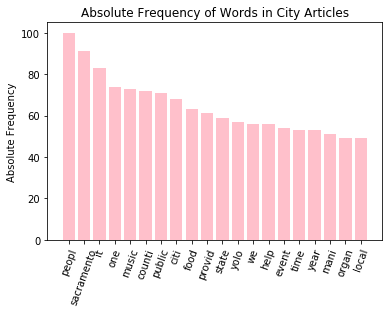

```python
df = pd.DataFrame.from_dict(city_counts, orient='index').reset_index()
df = df.sort_values(by=0, ascending=False)

word = list(df.ix[:,0])[3:23]
count = list(df.ix[:,1])[3:23]

word_indices = np.arange(20) # ORDERED INDICES

## PLOTTING
plt.bar(word_indices, count, color="pink")
plt.xticks(word_indices, word, rotation=70)
plt.ylabel("Absolute Frequency")
plt.title("Absolute Frequency of Words in City Articles")

plt.show()
```

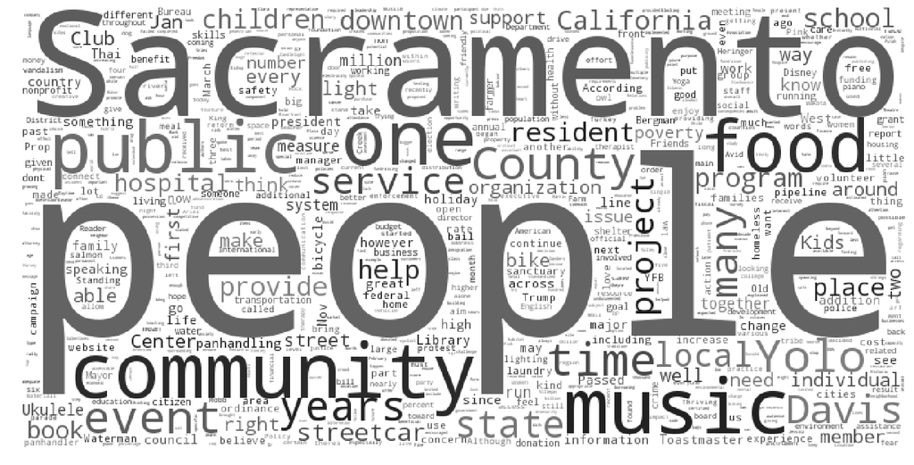

```python
this_text = list((" ".join(news_df["text"][news_df["source"] == "city"])).split(" "))
want = [item for item in this_text if item not in stopwords]
want = " ".join(want)


# GENERATE WORD CLOUD IMAGE
wc = WordCloud(background_color = "white", max_words=2000, stopwords=stopwords, width=800, height=400)

# GENERATE WORD CLOUD
wc.generate(want)

# COLORING
def grey_color_func(word, font_size, position, orientation, random_state=None, **kwargs):
    return "hsl(50, 0%%, %d%%)" % random.randint(10, 50)


# PLOTTING
plt.figure(figsize=(20,10))
plt.imshow(wc.recolor(color_func = grey_color_func, random_state=3))
plt.axis("off")
plt.tight_layout(pad=0)
plt.show()
```

## Finding the Top 3 Article Pairs

<font size=4.5> I chose specific stopwords on top of the stopwords from wordcloud. </font>

```python
# MY STOP WORDS
stopwords = STOPWORDS
more_stopwords = set(["said", "will", "really", "going", "might", "also", "come", "don't", "in", "UC", "Davis", "student", "students", "year", "city", "campus", "Day", "new", "News", "Last", "week", "Logs"])
stopwords = set(stopwords).union(more_stopwords)
```

<font size=4.5> I used the TfidfVectorizer function to create a sparse matrix. </font>

```python
# CREATE CORPUS
corpus_raw = ". ".join(news_df.text)

# INITIALIZE STEMMER
st = nltk.stem.LancasterStemmer()
corpus = set([st.stem(words) for words in nltk.tokenize.word_tokenize(corpus_raw)])

# VECTORIZE THIS CORPUS
vect = TfidfVectorizer(sublinear_tf=True, max_df=0.5, analyzer='word',stop_words=stopwords,vocabulary=corpus)
vect.fit(corpus)

# FUNCTION TO TOKENIZE
def getStems(doc):
    stems = set([st.stem(words) for words in nltk.tokenize.word_tokenize(doc)])
    return(stems)
```

```python
# GENERATES AND CALCULATES COSINE SIMILARITY SCORES
def getSparseMatrices(doc1,doc2):
    #print(len(doc1)+len(doc2))
    stems=[getStems(d) for d in [doc1,doc2]]
    doc1_vec=np.sum(vect.transform(stems[0]).toarray(),axis=0)
    doc2_vec=np.sum(vect.transform(stems[1]).toarray(),axis=0)
    cos_sim=np.dot(doc1_vec.T,doc2_vec)/(np.linalg.norm(doc1_vec)*np.linalg.norm(doc2_vec))
    return(cos_sim)
```

<font size=4.5> Let's create a pairwise similarity matrix where the diagonals are 0.  
**WARNING:** The following function in particular takes a long time to run. </font>

```python
# WARNING: UNCOMMENT THIS AFTER IT IS DONE LOADING
# WARNING: THIS TAKES A LONG TIME TO LOAD

# GETS THE SIMILARITY MATRIX WE WANT TO WORK WITH
sim_mat=[[getSparseMatrices(row,col) for row in news_df.text] for col in news_df.text]
```

```python
# CREATES MATRIX AND SETS DIAGONALS TO 0
similarity = np.array(sim_mat).reshape(120, 120)
np.fill_diagonal(similarity, 0)
# similarity
```

<font size=4.5> Now, we will triangularize to remove duplicate pairs, then catch any duplicates that have been posted more than once on listing or cross-posted using the for loop below. </font>

```python
# TRIANGULARIZE TO REMOVE DUPLICATES
sim_triangle = np.triu(similarity)
# print sim_triangle

# ERROR CATCHING
for i in range(len(sim_triangle)):
    for j in range(len(sim_triangle[i])):
        try:
            if round(sim_triangle[i][j],2) == 1:
                sim_triangle[i][j] = 0
        except:
            if sim_triangle[i][j] == 1:
                sim_triangle[i][j] = 0
```

<font size=4.5> The following values get indices we need to locate the highest similarity scores in the original news_df dataframe from 1.3. </font>

```python
# GET INDEX AND SCORE FOR CLOSEST MATCHING ARTICLE FOR EACH ARTICLE IN news_df
closest_article = np.argsort(sim_triangle)[:,119]
top_score = np.sort(sim_triangle)[:,119]
# print top_score
```

<font size=4.5> Now, we will create a dataframe of the results with the information calculated above. </font>

```python
# CREATE DATAFRAME WITH SIMILAR STUFF
sim_df  = pd.DataFrame([pd.Series(range(120)), closest_article, news_df.title, news_df.author, news_df.title.values[closest_article],news_df.author.values[closest_article], pd.Series(top_score)]).T
sim_df.columns = ["article_index", "closest_index", "title", "author", "sim_article", "sim_author","sim_score"]
sim_df.head()
```

|  | article_index | closest_index | title | author | sim_article | sim_author | sim_score |
| --- | --- | --- | --- | --- | --- | --- | --- |
| 0 | 0 | 102 | UC Davis students participate in UC-wide #NoDA... | Kaitlyn Cheung | NoDAPL protest erupts in downtown Davis | Samantha Solomon | 0.30912 |
| 1 | 1 | 35 | UC Davis holds first mental health conference | Jayashri Padmanabhan | UC Davis to host first ever mental health conf... | Jayashri Padmanabhan | 0.429239 |
| 2 | 2 | 25 | Last week in Senate | Demi Caceres | Last week in Senate | Yvonne Leong | 0.371135 |
| 3 | 3 | 55 | 2017 ASUCD Winter Elections Meet the Candidates | Alyssa Vandenberg | Student regent recruitment for the 2018-2019 s... | Demi Caceres | 0.33303 |
| 4 | 4 | 96 | Shields Library hosts new exhibit for Davis ce... | Ivan Valenzuela | Bike Campaign offers bicycles to those who can... | Raul Castellanos | 0.268643 |

```python
# SORT VALUES
sim_df = sim_df.sort_values(by="sim_score", ascending=False).iloc[::2,:]
sim_df.head()
```

|  | article_index | closest_index | title | author | sim_article | sim_author | sim_score |
| --- | --- | --- | --- | --- | --- | --- | --- |
| 1 | 1 | 35 | UC Davis holds first mental health conference | Jayashri Padmanabhan | UC Davis to host first ever mental health conf... | Jayashri Padmanabhan | 0.429239 |
| 12 | 12 | 15 | Last week in Senate | Yvonne Leong | Last week in Senate | Demi Caceres | 0.371135 |
| 15 | 15 | 25 | Last week in Senate | Demi Caceres | Last week in Senate | Yvonne Leong | 0.371135 |
| 88 | 88 | 114 | Helping the homeless | Andie Joldersma | The Yolo Food Bank addresses food insecurity | Anya Rehon | 0.344989 |
| 3 | 3 | 55 | 2017 ASUCD Winter Elections Meet the Candidates | Alyssa Vandenberg | Student regent recruitment for the 2018-2019 s... | Demi Caceres | 0.33303 |

```python
# TOP PAIR
common_1 = " / ".join(set.intersection(set(news_df["text"][1].split(" ")), set(news_df["text"][35].split(" "))))
print "Top Pair"
print "Number words in Common: " + str(len(common_1)) + "\nWords in Common: \n" + common_1 + "\n\n"

# SECOND TOP PAIR
common_2 = " / ".join(set.intersection(set(news_df["text"][15].split(" ")), set(news_df["text"][25].split(" "))))
print "Second Top Pair"
print "Number words in Common: " + str(len(common_2)) + "\nWords in Common: \n" + common_2 + "\n\n"


# THIRD TOP PAIR
common_3 = " / ".join(set.intersection(set(news_df["text"][88].split(" ")), set(news_df["text"][114].split(" "))))
print "Third Top Pair"
print "Number words in Common: " + str(len(common_3)) + "\nWords in Common: \n" + common_3 + "\n\n"
```

```
Top Pair
Number words in Common: 959
Words in Common:
help / able / workshops / involved / its / Porter / We / suicide / based / Chiang, / personal / Samantha / to / choose / then / them / She / spiritual / mental / people / Disability / are / really / workshops, / funding / for / selected / p.m. / health / Feb. / health. / body / be / we / after / ope…


Second Top Pair
Number words in Common: 522
Words in Common:
and / senators / Vice / Sofia / ASUCD / be / is / it / an / Commission / Internal / are / in / its / motion / for / no / began / that / Molodanof / p.m. / looking / to / 2 / resolution / Grewal / meeting / confirmations, / new / order / was / Affairs / then / Simran / Alex / passed / attend / Senato…


Third Top Pair
Number words in Common: 559
Words in Common:
and / help / be / being / money / is / some / number / one / Davis / through / are / in / population, / any / living / given / said / for / their / provide / assistance / people / able / next / access / to / program / health / provides / program, / November / many / local / do / an / way / emergency…
```

## Check if authors are the same to see if Algorithm is Working

<font size=4.5> In the above dataframe, I documented the authors. I will check if the authors are the same for similar articles. We should have a solid percentage of authors who are the same according to similarity scores. </font>

```python
from __future__ import division

# SEE WHERE AUTHORS ARE THE SAME
sim_df["same_author"] = (sim_df["author"] == sim_df["sim_author"])

# 8 PERCENT ARE ACTUALLY THE SAME AUTHORS
(len(sim_df[sim_df["same_author"] == True])/120) * 100
```

```
15.833333333333332
```

<font size=4.5> After the above calculation, 15.83% of the time, this algorithm finds that the article most similar to the article of interest was written by the same author. This is a good sign because people only have their own vocabulary. </font>

## Is this this corpus representative of the Aggie?

<font size=4.5> No. This corpus is definitely not representative of the Aggie because we did not collect a random sample of articles. This corpus is only representative of the four pages of the most recent City and Campus articles on the Aggie. </font>

# Resources

<font size=4.5> I have used the following websites as resources.

**TF-IDF Resources**

1. http://stackoverflow.com/questions/8897593/similarity-between-two-text-documents
2. http://stackoverflow.com/questions/12118720/python-tf-idf-cosine-to-find-document-similarity

# Collaborators

<font size=4.5> These are my friends.

1. Patrick Vacek
2. Ricky Safran
3. Niveditha Achanta
4. Graham Smith
5. Chad Pickering
6. Colin Santos
7. And so many more